# Final project

Jacky LU

title: “Further test for relationship of SST and salinity with larval fish abundance in southeast Australian estuarine”

Author: Chueh-Ning, Lu

Student ID: F10247009

1. Introduction -Larval fish surveys, categorized as part of ichthyoplankton (comprising fish eggs and larvae), serve as a valuable method for monitoring marine ecosystems and the composition of fish communities (Smith et al., 2018).

-The assessment of larval fish through surveys holds significant value in ecosystem monitoring due to the diverse array of oceanographic, biological, and anthropogenic factors that impact their abundance (Smith et al., 2018).

-Previous study located at east Australian coast shows a negative effect on larval abundance given strong upwelling favourable wind while a positive effect given strong downwelling favourable wind (Schilling et al., 2020). The reason why currents can affect larval abundance is possibly due to their moving ability (Schilling et al., 2019).

-East Australian Current significantly impacts the area between latitudes 32°–34°S. Within this region, the continental shelf experiences a noticeable alteration in the seasonal correlation between temperature and salinity. Consequently, the EAC might exhibit reduced local retention of larvae in this particular area (Suthers et al., 2011).

-Another previous study in the Gulf of Alaska points out that larval abundance is associated with sea temperature but depending on species (Doyle et al., 2009).

2. Methods and materials I use the larval fish data including samples between 30S and 36S from 1990 to 2016 to match up with the data utilized in Schilling et al., 2020. Different to the assumption of downwelling and upwelling current can affect the abundance of larval fish because of their moving ability in Schilling’s paper, I compared sea surface temperature and salinity with larval fish abundance. It is widely acknowledged that upwelling current can bring up the cold water from deep sea, so that surface temperature would be cooler and higher salinity. Schilling et al., 2020 pointed out that upwelling favourable wind has a negative effect on larval abundance, so the colder water should be with lower larval abundance.

Furthermore, to see more details, I split the data by regions and species. Three regions, each with 2 degrees of latitude, is set to see whether the difference from south to north is existing. Also, to know which species is affected the most exactly, I firstly concluded all larval abundance by species, and top five larval abundance is subset. The five fish species are Myctophidae, Sardinops sagax, Pseudocaranx georgianus, Trachurus novaezelandiae, and Bothidae.

Myctophidae refers to a family of small, deep-sea fish commonly known as lanternfishes. Lanternfishes are an essential part of the marine food chain, serving as a crucial food source for various larger marine animals, including whales, dolphins, squids, and larger fish. They exhibit diel vertical migration, moving vertically in the water column during the night to feed near the surface and descending to deeper waters during the day to avoid predators. Sardinops sagax, commonly known as the South American pilchard or Pacific sardine. They inhabit the open ocean, and are an important part of the marine food web, serving as prey for various larger predators, including marine mammals, seabirds, and larger fish species. Pseudocaranx georgianus, commonly known as the silver trevally or white trevally. These fish are found in coastal waters the most. The silver trevally typically inhabits shallow coastal waters, estuaries, and bays, often forming schools near rocky reefs or sandy bottoms. They are known for their strong and fast-swimming behavior. Trachurus novaezelandiae, commonly known as the yellowtail horse mackerel or jack mackerel. This species is native to the waters around New Zealand and parts of Australia, inhabiting coastal and offshore regions. Bothidae is a family of fish commonly known as the lefteye flounders or lefteye flounders. The family of this species is known for highly asymmetrical bodies with both eyes located on one side of the head. In the case of Bothidae, the eyes are positioned on the left side. They inhabit sandy or muddy bottoms along continental shelves and slopes.

For all subsets, I tested them firstly by correlation analysis to know their relationships with sea surface temperature and salinity. After, linear regression model is used to know how much these two factors affect larval abundance.

```r
library(Hmisc)
```

```r
library(corrplot)
library(MASS)
library(car)
library(interactions)
library(yarrr)
library(tidyr)
library(readr)
library(lme4)
library (lmerTest)
library(nlme)
library(ggplot2)
library(gvlma)
library(simpleboot)
library(DAAG)
library(bootstrap)
library(MBESS)
library(leaps)
library(sandwich)
library(dplyr)
library(vegan)
library(gridExtra)
```

Import the file and clean the data

```r
larvae = read.csv("C:/Users/j0893/OneDrive/桌面/Rcourse/Final project/data/Larvae.csv")

test = data.frame(larvae$Latitude, larvae$Longitude, larvae$Year_Local, larvae$Month_Local, larvae$Temperature_degC, larvae$Salinity_psu, larvae$Total)
test = na.omit(test)
colnames(test) = c("lat", "lon", "Year", "Month", "Temperature", "Salinity", "Total_abun")
test %>% group_by(Year) %>% summarise_all(mean) %>%  select(Year, Temperature, Salinity, Total_abun)
```

```
## # A tibble: 8 × 4
##    Year Temperature Salinity Total_abun
##   <int>       <dbl>    <dbl>      <dbl>
## 1  1994        21.1     35.5       257.
## 2  1998        21.9     35.4       444.
## 3  1999        24.4     35.3       217.
## 4  2004        18.7     35.6       342.
## 5  2010        19.4     35.5       213.
## 6  2014        17.9     35.4        16
## 7  2015        20.5     35.6       366.
## 8  2016        20.7     35.6       150.
```

```r
summary(test)
```

```
##       lat              lon             Year          Month
##  Min.   :-35.58   Min.   :150.8   Min.   :1994   Min.   : 1.000
##  1st Qu.:-33.96   1st Qu.:151.4   1st Qu.:1994   1st Qu.: 1.000
##  Median :-33.95   Median :151.7   Median :1998   Median : 4.000
##  Mean   :-33.17   Mean   :152.1   Mean   :2000   Mean   : 5.222
##  3rd Qu.:-32.17   3rd Qu.:153.0   3rd Qu.:2004   3rd Qu.: 9.000
##  Max.   :-30.00   Max.   :153.6   Max.   :2016   Max.   :12.000
##   Temperature       Salinity       Total_abun
##  Min.   :15.32   Min.   :34.50   Min.   :   0.0
##  1st Qu.:19.22   1st Qu.:35.35   1st Qu.:  65.5
##  Median :21.46   Median :35.56   Median : 152.0
##  Mean   :21.06   Mean   :35.47   Mean   : 285.0
##  3rd Qu.:22.59   3rd Qu.:35.65   3rd Qu.: 403.0
##  Max.   :27.53   Max.   :36.39   Max.   :3016.0
```

3. Results Low correlations of 0.1793662, for temperature and total abundance, and 0.2150289, for salinity and total abundance shows that these two factors have weak relationship. However, both temperature and salinity have a positive effect on total abundance though the effects are minor. The multiple linear regression model of temperature and salinity gives adjusted R-squared value of 0.05706, which indicates these two factors have very low effect on larval abundance.

```r
# Correlation test for total abundance
x = test$Temperature
y = test$Salinity
z = test$Total_abun
cor.test(x,z)
```

```
##
##  Pearson's product-moment correlation
##
## data:  x and z
## t = 4.0318, df = 489, p-value = 6.42e-05
## alternative hypothesis: true correlation is not equal to 0
## 95 percent confidence interval:
##  0.09234052 0.26367241
## sample estimates:
##       cor
## 0.1793662
```

```r
cor.test(y,z)
```

```
##
##  Pearson's product-moment correlation
##
## data:  y and z
## t = 4.8689, df = 489, p-value = 1.517e-06
## alternative hypothesis: true correlation is not equal to 0
## 95 percent confidence interval:
##  0.1289921 0.2978526
## sample estimates:
##       cor
## 0.2150289
```

```r
cor.test(x,y)
```

```
##
##  Pearson's product-moment correlation
##
## data:  x and y
## t = 6.8544, df = 489, p-value = 2.165e-11
## alternative hypothesis: true correlation is not equal to 0
## 95 percent confidence interval:
##  0.2131632 0.3747429
## sample estimates:
##       cor
## 0.2960697
```

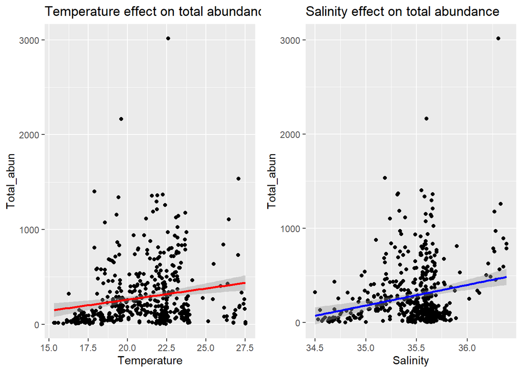

```r
plot1 = ggplot(test, aes(x = Temperature, y = Total_abun)) +
  geom_point() +
  stat_smooth(method = "lm", col = "red") +
  labs(title = "Temperature effect on total abundance")
plot2 = ggplot(test, aes(x = Salinity, y = Total_abun)) +
  geom_point() +
  stat_smooth(method = "lm", col = "blue") +
  labs(title = "Salinity effect on total abundance")

grid.arrange(plot1, plot2, nrow = 1)
```

```r
# linear model for total abundance
model1 <- lm(z ~ x, data = test)
summary(model1)
```

```
##
## Call:
## lm(formula = z ~ x, data = test)
##
## Residuals:
##    Min     1Q Median     3Q    Max
## -429.4 -196.7 -114.5  108.9 2695.1
##
## Coefficients:
##             Estimate Std. Error t value Pr(>|t|)
## (Intercept) -211.423    124.007  -1.705   0.0888 .
## x             23.566      5.845   4.032 6.42e-05 ***
## ---
## Signif. codes:  0 '***' 0.001 '**' 0.01 '*' 0.05 '.' 0.1 ' ' 1
##
## Residual standard error: 328.5 on 489 degrees of freedom
## Multiple R-squared:  0.03217,    Adjusted R-squared:  0.03019
## F-statistic: 16.26 on 1 and 489 DF,  p-value: 6.42e-05
```

```r
model2 <- lm(z ~ y, data = test)
summary(model2)
```

```
##
## Call:
## lm(formula = z ~ y, data = test)
##
## Residuals:
##    Min     1Q Median     3Q    Max
## -341.6 -230.8  -83.2  120.7 2548.7
##
## Coefficients:
##             Estimate Std. Error t value Pr(>|t|)
## (Intercept)  -7453.7     1589.5  -4.689 3.56e-06 ***
## y              218.2       44.8   4.869 1.52e-06 ***
## ---
## Signif. codes:  0 '***' 0.001 '**' 0.01 '*' 0.05 '.' 0.1 ' ' 1
##
## Residual standard error: 326.1 on 489 degrees of freedom
## Multiple R-squared:  0.04624,    Adjusted R-squared:  0.04429
## F-statistic: 23.71 on 1 and 489 DF,  p-value: 1.517e-06
```

```r
model3 <- lm(z ~ x + y, data = test)
summary(model3)
```

```
##
## Call:
## lm(formula = z ~ x + y, data = test)
##
## Residuals:
##     Min      1Q  Median      3Q     Max
## -374.92 -218.06  -74.39  103.80 2555.14
##
## Coefficients:
##              Estimate Std. Error t value Pr(>|t|)
## (Intercept) -6453.387   1619.845  -3.984 7.81e-05 ***
## x              16.662      6.034   2.761 0.005973 **
## y             180.057     46.593   3.864 0.000126 ***
## ---
## Signif. codes:  0 '***' 0.001 '**' 0.01 '*' 0.05 '.' 0.1 ' ' 1
##
## Residual standard error: 324 on 488 degrees of freedom
## Multiple R-squared:  0.06091,    Adjusted R-squared:  0.05706
## F-statistic: 15.83 on 2 and 488 DF,  p-value: 2.19e-07
```

```r
# Split the data by regions, 2 degrees of latitude as 1 region
test_south <- test %>% filter(lat > -36 & lat < -34)
test_middle <- test %>% filter(lat > -34 & lat < -32)
test_north <- test %>% filter(lat > -32 & lat < -30)

x_S = test_south$Temperature
y_S = test_south$Salinity
z_S = test_south$Total_abun
cor.test(x_S,z_S)
```

```
##
##  Pearson's product-moment correlation
##
## data:  x_S and z_S
## t = 4.6764, df = 65, p-value = 1.522e-05
## alternative hypothesis: true correlation is not equal to 0
## 95 percent confidence interval:
##  0.2973686 0.6621437
## sample estimates:
##       cor
## 0.5017378
```

```r
cor.test(y_S,z_S)
```

```
##
##  Pearson's product-moment correlation
##
## data:  y_S and z_S
## t = 2.7518, df = 65, p-value = 0.007671
## alternative hypothesis: true correlation is not equal to 0
## 95 percent confidence interval:
##  0.08978276 0.52267718
## sample estimates:
##       cor
## 0.3230248
```

```r
x_M = test_middle$Temperature
y_M = test_middle$Salinity
z_M = test_middle$Total_abun
cor.test(x_M,z_M)
```

```
##
##  Pearson's product-moment correlation
##
## data:  x_M and z_M
## t = 3.4239, df = 276, p-value = 0.0007109
## alternative hypothesis: true correlation is not equal to 0
## 95 percent confidence interval:
##  0.08626032 0.31208684
## sample estimates:
##       cor
## 0.2018549
```

```r
cor.test(y_M,z_M)
```

```
##
##  Pearson's product-moment correlation
##
## data:  y_M and z_M
## t = 5.0926, df = 276, p-value = 6.549e-07
## alternative hypothesis: true correlation is not equal to 0
## 95 percent confidence interval:
##  0.1817024 0.3970342
## sample estimates:
##       cor
## 0.2930805
```

```r
x_N = test_north$Temperature
y_N = test_north$Salinity
z_N = test_north$Total_abun
cor.test(x_N,z_N)
```

```
##
##  Pearson's product-moment correlation
##
## data:  x_N and z_N
## t = -2.4424, df = 111, p-value = 0.01617
## alternative hypothesis: true correlation is not equal to 0
## 95 percent confidence interval:
##  -0.39412069 -0.04289238
## sample estimates:
##        cor
## -0.2258328
```

```r
cor.test(y_N,z_N)
```

```
##
##  Pearson's product-moment correlation
##
## data:  y_N and z_N
## t = -1.5502, df = 111, p-value = 0.1239
## alternative hypothesis: true correlation is not equal to 0
## 95 percent confidence interval:
##  -0.32165327  0.04023866
## sample estimates:
##        cor
## -0.1455733
```

```r
model_Temp_S <- lm(z_S ~ x_S, data = test_south)
summary(model_Temp_S)
```

```
##
## Call:
## lm(formula = z_S ~ x_S, data = test_south)
##
## Residuals:
##     Min      1Q  Median      3Q     Max
## -388.80 -146.49  -23.73   64.63  734.84
##
## Coefficients:
##             Estimate Std. Error t value Pr(>|t|)
## (Intercept) -1132.05     294.80  -3.840 0.000281 ***
## x_S            66.37      14.19   4.676 1.52e-05 ***
## ---
## Signif. codes:  0 '***' 0.001 '**' 0.01 '*' 0.05 '.' 0.1 ' ' 1
##
## Residual standard error: 262.3 on 65 degrees of freedom
## Multiple R-squared:  0.2517, Adjusted R-squared:  0.2402
## F-statistic: 21.87 on 1 and 65 DF,  p-value: 1.522e-05
```

```r
model_Salt_S <- lm(z_S ~ y_S, data = test_south)
summary(model_Salt_S)
```

```
##
## Call:
## lm(formula = z_S ~ y_S, data = test_south)
##
## Residuals:
##     Min      1Q  Median      3Q     Max
## -251.49 -178.77 -128.04   82.76  893.70
##
## Coefficients:
##             Estimate Std. Error t value Pr(>|t|)
## (Intercept) -12330.9     4567.7  -2.700  0.00884 **
## y_S            353.0      128.3   2.752  0.00767 **
## ---
## Signif. codes:  0 '***' 0.001 '**' 0.01 '*' 0.05 '.' 0.1 ' ' 1
##
## Residual standard error: 287 on 65 degrees of freedom
## Multiple R-squared:  0.1043, Adjusted R-squared:  0.09057
## F-statistic: 7.573 on 1 and 65 DF,  p-value: 0.007671
```

```r
model_south <- lm(z_S ~ x_S + y_S, data = test_south)
summary(model_south)
```

```
##
## Call:
## lm(formula = z_S ~ x_S + y_S, data = test_south)
##
## Residuals:
##     Min      1Q  Median      3Q     Max
## -372.61 -163.10  -35.38   67.05  747.72
##
## Coefficients:
##             Estimate Std. Error t value Pr(>|t|)
## (Intercept) -6331.67    4456.37  -1.421 0.160225
## x_S            58.77      15.57   3.774 0.000354 ***
## y_S           150.43     128.64   1.169 0.246608
## ---
## Signif. codes:  0 '***' 0.001 '**' 0.01 '*' 0.05 '.' 0.1 ' ' 1
##
## Residual standard error: 261.6 on 64 degrees of freedom
## Multiple R-squared:  0.2674, Adjusted R-squared:  0.2445
## F-statistic: 11.68 on 2 and 64 DF,  p-value: 4.741e-05
```

```r
model_Temp_M <- lm(z_M ~ x_M, data = test_middle)
summary(model_Temp_M)
```

```
##
## Call:
## lm(formula = z_M ~ x_M, data = test_middle)
##
## Residuals:
##     Min      1Q  Median      3Q     Max
## -351.42 -172.87  -98.04   97.55 2687.66
##
## Coefficients:
##             Estimate Std. Error t value Pr(>|t|)
## (Intercept) -349.155    180.000  -1.940 0.053429 .
## x_M           29.991      8.759   3.424 0.000711 ***
## ---
## Signif. codes:  0 '***' 0.001 '**' 0.01 '*' 0.05 '.' 0.1 ' ' 1
##
## Residual standard error: 328.8 on 276 degrees of freedom
## Multiple R-squared:  0.04075,    Adjusted R-squared:  0.03727
## F-statistic: 11.72 on 1 and 276 DF,  p-value: 0.0007109
```

```r
model_Salt_M <- lm(z_M ~ y_M, data = test_middle)
summary(model_Salt_M)
```

```
##
## Call:
## lm(formula = z_M ~ y_M, data = test_middle)
##
## Residuals:
##     Min      1Q  Median      3Q     Max
## -327.22 -228.59  -44.53  106.80 2524.08
##
## Coefficients:
##             Estimate Std. Error t value Pr(>|t|)
## (Intercept)  -9123.2     1843.3  -4.949 1.30e-06 ***
## y_M            264.8       52.0   5.093 6.55e-07 ***
## ---
## Signif. codes:  0 '***' 0.001 '**' 0.01 '*' 0.05 '.' 0.1 ' ' 1
##
## Residual standard error: 320.9 on 276 degrees of freedom
## Multiple R-squared:  0.0859, Adjusted R-squared:  0.08258
## F-statistic: 25.94 on 1 and 276 DF,  p-value: 6.549e-07
```

```r
model_middle <- lm(z_M ~ x_M + y_M, data = test_south)
summary(model_middle)
```

```
##
## Call:
## lm(formula = z_M ~ x_M + y_M, data = test_south)
##
## Residuals:
##    Min     1Q Median     3Q    Max
## -338.0 -223.0  -49.7  106.0 2528.6
##
## Coefficients:
##              Estimate Std. Error t value Pr(>|t|)
## (Intercept) -8149.578   2019.274  -4.036 7.06e-05 ***
## x_M            11.513      9.783   1.177 0.240313
## y_M           230.705     59.496   3.878 0.000132 ***
## ---
## Signif. codes:  0 '***' 0.001 '**' 0.01 '*' 0.05 '.' 0.1 ' ' 1
##
## Residual standard error: 320.7 on 275 degrees of freedom
## Multiple R-squared:  0.09048,    Adjusted R-squared:  0.08386
## F-statistic: 13.68 on 2 and 275 DF,  p-value: 2.172e-06
```

```r
model_Temp_N <- lm(z_N ~ x_N, data = test_north)
summary(model_Temp_N)
```

```
##
## Call:
## lm(formula = z_N ~ x_N, data = test_north)
##
## Residuals:
##    Min     1Q Median     3Q    Max
## -423.7 -242.7 -102.2  132.2 1289.6
##
## Coefficients:
##             Estimate Std. Error t value Pr(>|t|)
## (Intercept)  1064.20     283.24   3.757 0.000276 ***
## x_N           -30.19      12.36  -2.442 0.016168 *
## ---
## Signif. codes:  0 '***' 0.001 '**' 0.01 '*' 0.05 '.' 0.1 ' ' 1
##
## Residual standard error: 341.9 on 111 degrees of freedom
## Multiple R-squared:  0.051,  Adjusted R-squared:  0.04245
## F-statistic: 5.965 on 1 and 111 DF,  p-value: 0.01617
```

```r
model_Salt_N <- lm(z_N ~ y_N, data = test_north)
summary(model_Salt_N)
```

```
##
## Call:
## lm(formula = z_N ~ y_N, data = test_north)
##
## Residuals:
##    Min     1Q Median     3Q    Max
## -408.2 -248.7 -131.7  207.4 1079.0
##
## Coefficients:
##             Estimate Std. Error t value Pr(>|t|)
## (Intercept)  12288.0     7683.6   1.599    0.113
## y_N           -336.2      216.9  -1.550    0.124
##
## Residual standard error: 347.2 on 111 degrees of freedom
## Multiple R-squared:  0.02119,    Adjusted R-squared:  0.01237
## F-statistic: 2.403 on 1 and 111 DF,  p-value: 0.1239
```

```r
model_north <- lm(z_N ~ x_N + y_N, data = test_north)
summary(model_north)
```

```
##
## Call:
## lm(formula = z_N ~ x_N + y_N, data = test_north)
##
## Residuals:
##    Min     1Q Median     3Q    Max
## -518.5 -217.4 -114.8  173.9 1199.4
##
## Coefficients:
##             Estimate Std. Error t value Pr(>|t|)
## (Intercept) 28278.71    8404.30   3.365 0.001055 **
## x_N           -50.96      13.48  -3.779 0.000256 ***
## y_N          -754.81     232.98  -3.240 0.001582 **
## ---
## Signif. codes:  0 '***' 0.001 '**' 0.01 '*' 0.05 '.' 0.1 ' ' 1
##
## Residual standard error: 328.1 on 110 degrees of freedom
## Multiple R-squared:  0.1337, Adjusted R-squared:  0.1179
## F-statistic: 8.486 on 2 and 110 DF,  p-value: 0.0003738
```

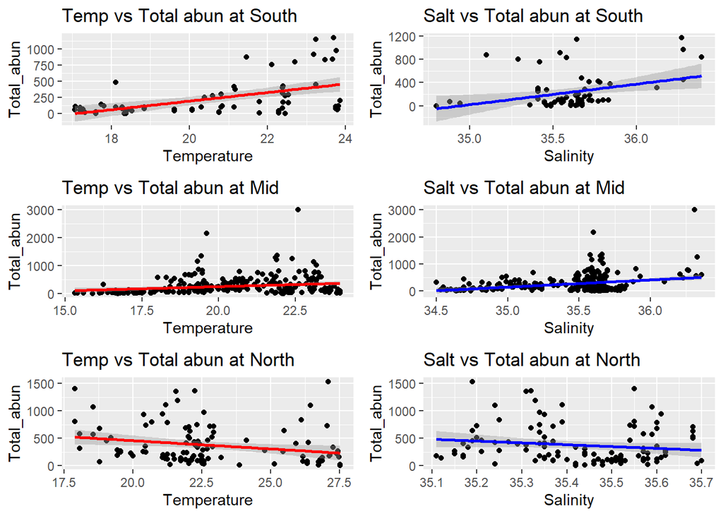

```r
plot_SouthTemp <- ggplot(test_south, aes(x = Temperature, y = Total_abun)) +
  geom_point() +
  stat_smooth(method = "lm", col = "red") +
  labs(title = "Temp vs Total abun at South")

plot_SouthSalt <- ggplot(test_south, aes(x = Salinity, y = Total_abun)) +
  geom_point() +
  stat_smooth(method = "lm", col = "blue") +
  labs(title = "Salt vs Total abun at South")

plot_MidTemp <- ggplot(test_middle, aes(x = Temperature, y = Total_abun)) +
  geom_point() +
  stat_smooth(method = "lm", col = "red") +
  labs(title = "Temp vs Total abun at Mid")

plot_MidSalt <- ggplot(test_middle, aes(x = Salinity, y = Total_abun)) +
  geom_point() +
  stat_smooth(method = "lm", col = "blue") +
  labs(title = "Salt vs Total abun at Mid")

plot_NorTemp <- ggplot(test_north, aes(x = Temperature, y = Total_abun)) +
  geom_point() +
  stat_smooth(method = "lm", col = "red") +
  labs(title = "Temp vs Total abun at North")

plot_NorSalt <- ggplot(test_north, aes(x = Salinity, y = Total_abun)) +
  geom_point() +
  stat_smooth(method = "lm", col = "blue") +
  labs(title = "Salt vs Total abun at North")

grid.arrange(plot_SouthTemp, plot_SouthSalt, plot_MidTemp, plot_MidSalt,plot_NorTemp, plot_NorSalt, nrow = 3)
```

Sea surface temperature has more important relationship with Myctophidae (correlation = 0.15) and Sardinops sagax (correlation = -0.15), and a weak negative relationship with Bothidae (correlation = -0.04). Salinity also has relatively stronger relationship compared to other species with Myctophidae (correlation = 0.28), Trachurus novaezelandiae (correlation = 0.18), and Pseudocaranx georgianus (correlation = 0.21). All linear regression models show minor effect from temperature and salinity on the abundance of these species.

```r
# First, calculate the abundance of each species and pick top 5
larve_selected <- larvae %>% select(-c(Project:QC_flag))
column_sums <- colSums(larve_selected, na.rm = TRUE)
sorted_sums <- sort(column_sums, decreasing = TRUE)
top_five_species <- head(sorted_sums, 5)

# Create another dataset to work conveniently
test_spe = data.frame(larvae$Latitude, larvae$Longitude, larvae$Year_Local, larvae$Month_Local, larvae$Temperature_degC, larvae$Salinity_psu,
                  larvae$ Myctophidae_Myctophidae_37122000, larvae$ Clupeidae_Sardinops.sagax_37085002, larvae$Carangidae_Pseudocaranx.georgianus_37337062,
                  larvae$Carangidae_Trachurus.novaezelandiae_37337003, larvae$Bothidae_Bothidae_37460922)

colnames(test_spe) = c("lat", "lon", "Year", "Month", "Temperature", "Salinity",
                   "Myctophidae", "Sardin", "Pseudocaranx", "Trachurus", "Bothidae")

x_spe = test_spe$Temperature
y_spe = test_spe$Salinity
Myc = test_spe$Myctophidae
Sard = test_spe$Sardin
Pseudo = test_spe$Pseudocaranx
Tra = test_spe$Trachurus
Bot = test_spe$Bothidae

cor.test(x_spe, Myc)
```

```
##
##  Pearson's product-moment correlation
##
## data:  x_spe and Myc
## t = 3.384, df = 516, p-value = 0.0007687
## alternative hypothesis: true correlation is not equal to 0
## 95 percent confidence interval:
##  0.06198159 0.23057230
## sample estimates:
##      cor
## 0.147347
```

```r
cor.test(x_spe, Sard)
```

```
##
##  Pearson's product-moment correlation
##
## data:  x_spe and Sard
## t = -3.5603, df = 516, p-value = 0.0004047
## alternative hypothesis: true correlation is not equal to 0
## 95 percent confidence interval:
##  -0.23782334 -0.06962022
## sample estimates:
##        cor
## -0.1548437
```

```r
cor.test(x_spe, Pseudo)
```

```
##
##  Pearson's product-moment correlation
##
## data:  x_spe and Pseudo
## t = 0.72531, df = 516, p-value = 0.4686
## alternative hypothesis: true correlation is not equal to 0
## 95 percent confidence interval:
##  -0.05438802  0.11774225
## sample estimates:
##        cor
## 0.03191375
```

```r
cor.test(x_spe, Tra)
```

```
##
##  Pearson's product-moment correlation
##
## data:  x_spe and Tra
## t = 0.24883, df = 516, p-value = 0.8036
## alternative hypothesis: true correlation is not equal to 0
## 95 percent confidence interval:
##  -0.07527001  0.09701394
## sample estimates:
##        cor
## 0.01095325
```

```r
cor.test(x_spe, Bot)
```

```
##
##  Pearson's product-moment correlation
##
## data:  x_spe and Bot
## t = -0.91185, df = 516, p-value = 0.3623
## alternative hypothesis: true correlation is not equal to 0
## 95 percent confidence interval:
##  -0.12582702  0.04620229
## sample estimates:
##         cor
## -0.04010959
```

```r
cor.test(y_spe, Myc)
```

```
##
##  Pearson's product-moment correlation
##
## data:  y_spe and Myc
## t = 6.5515, df = 487, p-value = 1.452e-10
## alternative hypothesis: true correlation is not equal to 0
## 95 percent confidence interval:
##  0.2010002 0.3640842
## sample estimates:
##    cor
## 0.2846
```

```r
cor.test(y_spe, Sard)
```

```
##
##  Pearson's product-moment correlation
##
## data:  y_spe and Sard
## t = 1.3165, df = 487, p-value = 0.1886
## alternative hypothesis: true correlation is not equal to 0
## 95 percent confidence interval:
##  -0.02927572  0.14744482
## sample estimates:
##        cor
## 0.05955114
```

```r
cor.test(y_spe, Pseudo)
```

```
##
##  Pearson's product-moment correlation
##
## data:  y_spe and Pseudo
## t = 4.7488, df = 487, p-value = 2.696e-06
## alternative hypothesis: true correlation is not equal to 0
## 95 percent confidence interval:
##  0.1240124 0.2935673
## sample estimates:
##       cor
## 0.2103713
```

```r
cor.test(y_spe, Tra)
```

```
##
##  Pearson's product-moment correlation
##
## data:  y_spe and Tra
## t = 4.099, df = 487, p-value = 4.861e-05
## alternative hypothesis: true correlation is not equal to 0
## 95 percent confidence interval:
##  0.09549498 0.26696997
## sample estimates:
##       cor
## 0.1826209
```

```r
cor.test(y_spe, Bot)
```

```
##
##  Pearson's product-moment correlation
##
## data:  y_spe and Bot
## t = 0.82781, df = 487, p-value = 0.4082
## alternative hypothesis: true correlation is not equal to 0
## 95 percent confidence interval:
##  -0.05135777  0.12573953
## sample estimates:
##        cor
## 0.03748521
```

```r
model_Temp_Myc <- lm(Myc ~ x_spe, data = test_spe)
summary(model_Temp_Myc)
```

```
##
## Call:
## lm(formula = Myc ~ x_spe, data = test_spe)
##
## Residuals:
##     Min      1Q  Median      3Q     Max
## -102.32  -60.45  -34.69    1.76 1092.83
##
## Coefficients:
##             Estimate Std. Error t value Pr(>|t|)
## (Intercept)  -95.051     45.619  -2.084 0.037691 *
## x_spe          7.169      2.119   3.384 0.000769 ***
## ---
## Signif. codes:  0 '***' 0.001 '**' 0.01 '*' 0.05 '.' 0.1 ' ' 1
##
## Residual standard error: 133.4 on 516 degrees of freedom
##   (因為不存在，1062 個觀察量被刪除了)
## Multiple R-squared:  0.02171,    Adjusted R-squared:  0.01982
## F-statistic: 11.45 on 1 and 516 DF,  p-value: 0.0007687
```

```r
model_Temp_Sard <- lm(Sard ~ x_spe, data = test_spe)
summary(model_Temp_Sard)
```

```
##
## Call:
## lm(formula = Sard ~ x_spe, data = test_spe)
##
## Residuals:
##     Min      1Q  Median      3Q     Max
##  -50.17  -23.86  -12.82   -4.86 1321.43
##
## Coefficients:
##             Estimate Std. Error t value Pr(>|t|)
## (Intercept)  134.440     33.267   4.041 6.13e-05 ***
## x_spe         -5.501      1.545  -3.560 0.000405 ***
## ---
## Signif. codes:  0 '***' 0.001 '**' 0.01 '*' 0.05 '.' 0.1 ' ' 1
##
## Residual standard error: 97.27 on 516 degrees of freedom
##   (因為不存在，1062 個觀察量被刪除了)
## Multiple R-squared:  0.02398,    Adjusted R-squared:  0.02209
## F-statistic: 12.68 on 1 and 516 DF,  p-value: 0.0004047
```

```r
model_Temp_Pseudo <- lm(Pseudo ~ x_spe, data = test_spe)
summary(model_Temp_Pseudo)
```

```
##
## Call:
## lm(formula = Pseudo ~ x_spe, data = test_spe)
##
## Residuals:
##     Min      1Q  Median      3Q     Max
##  -4.480  -2.999  -2.618  -1.988 284.020
##
## Coefficients:
##             Estimate Std. Error t value Pr(>|t|)
## (Intercept)  -2.2843     6.9036  -0.331    0.741
## x_spe         0.2325     0.3206   0.725    0.469
##
## Residual standard error: 20.19 on 516 degrees of freedom
##   (因為不存在，1062 個觀察量被刪除了)
## Multiple R-squared:  0.001018,   Adjusted R-squared:  -0.0009175
## F-statistic: 0.5261 on 1 and 516 DF,  p-value: 0.4686
```

```r
model_Temp_Tra <- lm(Tra ~ x_spe, data = test_spe)
summary(model_Temp_Tra)
```

```
##
## Call:
## lm(formula = Tra ~ x_spe, data = test_spe)
##
## Residuals:
##     Min      1Q  Median      3Q     Max
##  -19.26  -16.48  -15.30  -13.55 2087.48
##
## Coefficients:
##             Estimate Std. Error t value Pr(>|t|)
## (Intercept)   6.9860    36.5055   0.191    0.848
## x_spe         0.4218     1.6954   0.249    0.804
##
## Residual standard error: 106.7 on 516 degrees of freedom
##   (因為不存在，1062 個觀察量被刪除了)
## Multiple R-squared:  0.00012,    Adjusted R-squared:  -0.001818
## F-statistic: 0.06191 on 1 and 516 DF,  p-value: 0.8036
```

```r
model_Temp_Bot <- lm(Bot ~ x_spe, data = test_spe)
summary(model_Temp_Bot)
```

```
##
## Call:
## lm(formula = Bot ~ x_spe, data = test_spe)
##
## Residuals:
##    Min     1Q Median     3Q    Max
##  -9.41  -7.15  -5.48  -1.66 365.01
##
## Coefficients:
##             Estimate Std. Error t value Pr(>|t|)
## (Intercept)  14.6621     8.0973   1.811   0.0708 .
## x_spe        -0.3429     0.3760  -0.912   0.3623
## ---
## Signif. codes:  0 '***' 0.001 '**' 0.01 '*' 0.05 '.' 0.1 ' ' 1
##
## Residual standard error: 23.68 on 516 degrees of freedom
##   (因為不存在，1062 個觀察量被刪除了)
## Multiple R-squared:  0.001609,   Adjusted R-squared:  -0.0003261
## F-statistic: 0.8315 on 1 and 516 DF,  p-value: 0.3623
```

```r
model_Salt_Myc <- lm(Myc ~ y_spe, data = test_spe)
summary(model_Salt_Myc)
```

```
##
## Call:
## lm(formula = Myc ~ y_spe, data = test_spe)
##
## Residuals:
##     Min      1Q  Median      3Q     Max
## -148.80  -65.80  -36.37   18.46 1165.72
##
## Coefficients:
##             Estimate Std. Error t value Pr(>|t|)
## (Intercept) -4187.72     648.46  -6.458 2.57e-10 ***
## y_spe         119.75      18.28   6.552 1.45e-10 ***
## ---
## Signif. codes:  0 '***' 0.001 '**' 0.01 '*' 0.05 '.' 0.1 ' ' 1
##
## Residual standard error: 132.4 on 487 degrees of freedom
##   (因為不存在，1091 個觀察量被刪除了)
## Multiple R-squared:  0.081,  Adjusted R-squared:  0.07911
## F-statistic: 42.92 on 1 and 487 DF,  p-value: 1.452e-10
```

```r
model_Salt_Sard <- lm(Sard ~ y_spe, data = test_spe)
summary(model_Salt_Sard)
```

```
##
## Call:
## lm(formula = Sard ~ y_spe, data = test_spe)
##
## Residuals:
##     Min      1Q  Median      3Q     Max
##  -34.28  -20.52  -17.61  -11.90 1328.21
##
## Coefficients:
##             Estimate Std. Error t value Pr(>|t|)
## (Intercept)  -633.16     494.26  -1.281    0.201
## y_spe          18.34      13.93   1.317    0.189
##
## Residual standard error: 101 on 487 degrees of freedom
##   (因為不存在，1091 個觀察量被刪除了)
## Multiple R-squared:  0.003546,   Adjusted R-squared:  0.0015
## F-statistic: 1.733 on 1 and 487 DF,  p-value: 0.1886
```

```r
model_Salt_Pseudo <- lm(Pseudo ~ y_spe, data = test_spe)
summary(model_Salt_Pseudo)
```

```
##
## Call:
## lm(formula = Pseudo ~ y_spe, data = test_spe)
##
## Residuals:
##     Min      1Q  Median      3Q     Max
## -11.153  -3.629  -2.425  -0.037 194.763
##
## Coefficients:
##             Estimate Std. Error t value Pr(>|t|)
## (Intercept) -353.895     74.943  -4.722 3.06e-06 ***
## y_spe         10.032      2.112   4.749 2.70e-06 ***
## ---
## Signif. codes:  0 '***' 0.001 '**' 0.01 '*' 0.05 '.' 0.1 ' ' 1
##
## Residual standard error: 15.31 on 487 degrees of freedom
##   (因為不存在，1091 個觀察量被刪除了)
## Multiple R-squared:  0.04426,    Adjusted R-squared:  0.04229
## F-statistic: 22.55 on 1 and 487 DF,  p-value: 2.696e-06
```

```r
model_Salt_Tra <- lm(Tra ~ y_spe, data = test_spe)
summary(model_Salt_Tra)
```

```
##
## Call:
## lm(formula = Tra ~ y_spe, data = test_spe)
##
## Residuals:
##     Min      1Q  Median      3Q     Max
##  -67.93  -23.06  -14.49    3.16 2040.74
##
## Coefficients:
##             Estimate Std. Error t value Pr(>|t|)
## (Intercept) -2052.29     504.27  -4.070 5.49e-05 ***
## y_spe          58.26      14.21   4.099 4.86e-05 ***
## ---
## Signif. codes:  0 '***' 0.001 '**' 0.01 '*' 0.05 '.' 0.1 ' ' 1
##
## Residual standard error: 103 on 487 degrees of freedom
##   (因為不存在，1091 個觀察量被刪除了)
## Multiple R-squared:  0.03335,    Adjusted R-squared:  0.03137
## F-statistic:  16.8 on 1 and 487 DF,  p-value: 4.861e-05
```

```r
model_Salt_Bot <- lm(Bot ~ y_spe, data = test_spe)
summary(model_Salt_Bot)
```

```
##
## Call:
## lm(formula = Bot ~ y_spe, data = test_spe)
##
## Residuals:
##    Min     1Q Median     3Q    Max
##  -8.88  -7.65  -5.74  -2.21 365.13
##
## Coefficients:
##             Estimate Std. Error t value Pr(>|t|)
## (Intercept)  -91.016    119.081  -0.764    0.445
## y_spe          2.779      3.357   0.828    0.408
##
## Residual standard error: 24.32 on 487 degrees of freedom
##   (因為不存在，1091 個觀察量被刪除了)
## Multiple R-squared:  0.001405,   Adjusted R-squared:  -0.0006454
## F-statistic: 0.6853 on 1 and 487 DF,  p-value: 0.4082
```

```r
model_Myc <- lm(Myc ~ x_spe + y_spe, data = test_spe)
summary(model_Myc)
```

```
##
## Call:
## lm(formula = Myc ~ x_spe + y_spe, data = test_spe)
##
## Residuals:
##     Min      1Q  Median      3Q     Max
## -144.63  -63.09  -37.09   19.91 1119.94
##
## Coefficients:
##              Estimate Std. Error t value Pr(>|t|)
## (Intercept) -3779.670    660.223  -5.725 1.81e-08 ***
## x_spe           6.863      2.450   2.801   0.0053 **
## y_spe         104.172     18.984   5.487 6.58e-08 ***
## ---
## Signif. codes:  0 '***' 0.001 '**' 0.01 '*' 0.05 '.' 0.1 ' ' 1
##
## Residual standard error: 131.5 on 486 degrees of freedom
##   (因為不存在，1091 個觀察量被刪除了)
## Multiple R-squared:  0.09559,    Adjusted R-squared:  0.09187
## F-statistic: 25.68 on 2 and 486 DF,  p-value: 2.49e-11
```

```r
model_Sard <- lm(Sard ~ x_spe + y_spe, data = test_spe)
summary(model_Sard)
```

```
##
## Call:
## lm(formula = Sard ~ x_spe + y_spe, data = test_spe)
##
## Residuals:
##     Min      1Q  Median      3Q     Max
##  -55.68  -23.28  -15.83   -3.46 1315.08
##
## Coefficients:
##              Estimate Std. Error t value Pr(>|t|)
## (Intercept) -1081.701    498.821  -2.169   0.0306 *
## x_spe          -7.544      1.851  -4.075 5.38e-05 ***
## y_spe          35.465     14.343   2.473   0.0138 *
## ---
## Signif. codes:  0 '***' 0.001 '**' 0.01 '*' 0.05 '.' 0.1 ' ' 1
##
## Residual standard error: 99.37 on 486 degrees of freedom
##   (因為不存在，1091 個觀察量被刪除了)
## Multiple R-squared:  0.03646,    Adjusted R-squared:  0.0325
## F-statistic: 9.196 on 2 and 486 DF,  p-value: 0.0001202
```

```r
model_Pseudo <- lm(Pseudo ~ x_spe + y_spe, data = test_spe)
summary(model_Pseudo)
```

```
##
## Call:
## lm(formula = Pseudo ~ x_spe + y_spe, data = test_spe)
##
## Residuals:
##     Min      1Q  Median      3Q     Max
## -11.066  -3.654  -2.647   0.077 194.751
##
## Coefficients:
##              Estimate Std. Error t value Pr(>|t|)
## (Intercept) -363.8344    76.8895  -4.732 2.92e-06 ***
## x_spe         -0.1672     0.2854  -0.586    0.558
## y_spe         10.4110     2.2109   4.709 3.25e-06 ***
## ---
## Signif. codes:  0 '***' 0.001 '**' 0.01 '*' 0.05 '.' 0.1 ' ' 1
##
## Residual standard error: 15.32 on 486 degrees of freedom
##   (因為不存在，1091 個觀察量被刪除了)
## Multiple R-squared:  0.04493,    Adjusted R-squared:  0.041
## F-statistic: 11.43 on 2 and 486 DF,  p-value: 1.408e-05
```

```r
model_Tra <- lm(Tra ~ x_spe + y_spe, data = test_spe)
summary(model_Tra)
```

```
##
## Call:
## lm(formula = Tra ~ x_spe + y_spe, data = test_spe)
##
## Residuals:
##     Min      1Q  Median      3Q     Max
##  -67.12  -24.52  -11.34    7.16 2040.16
##
## Coefficients:
##              Estimate Std. Error t value Pr(>|t|)
## (Intercept) -2144.726    517.198  -4.147 3.98e-05 ***
## x_spe          -1.555      1.920  -0.810    0.418
## y_spe          61.793     14.872   4.155 3.84e-05 ***
## ---
## Signif. codes:  0 '***' 0.001 '**' 0.01 '*' 0.05 '.' 0.1 ' ' 1
##
## Residual standard error: 103 on 486 degrees of freedom
##   (因為不存在，1091 個觀察量被刪除了)
## Multiple R-squared:  0.03465,    Adjusted R-squared:  0.03068
## F-statistic: 8.723 on 2 and 486 DF,  p-value: 0.0001897
```

```r
model_Bot <- lm(Bot ~ x_spe + y_spe, data = test_spe)
summary(model_Bot)
```

```
##
## Call:
## lm(formula = Bot ~ x_spe + y_spe, data = test_spe)
##
## Residuals:
##    Min     1Q Median     3Q    Max
##  -9.81  -7.41  -5.92  -1.78 364.46
##
## Coefficients:
##              Estimate Std. Error t value Pr(>|t|)
## (Intercept) -112.2825   122.1379  -0.919    0.358
## x_spe         -0.3577     0.4533  -0.789    0.430
## y_spe          3.5905     3.5120   1.022    0.307
##
## Residual standard error: 24.33 on 486 degrees of freedom
##   (因為不存在，1091 個觀察量被刪除了)
## Multiple R-squared:  0.002683,   Adjusted R-squared:  -0.001421
## F-statistic: 0.6537 on 2 and 486 DF,  p-value: 0.5206
```

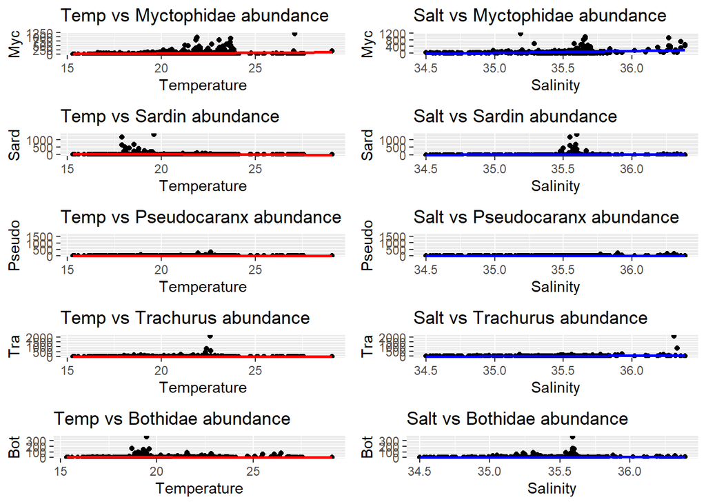

```r
plot_temp_Myc <- ggplot(test_spe, aes(x = Temperature, y = Myc)) +
  geom_point() +
  stat_smooth(method = "lm", col = "red") +
  labs(title = "Temp vs Myctophidae abundance")

plot_salt_Myc <- ggplot(test_spe, aes(x = Salinity, y = Myc)) +
  geom_point() +
  stat_smooth(method = "lm", col = "blue") +
  labs(title = "Salt vs Myctophidae abundance")

plot_temp_Sard <- ggplot(test_spe, aes(x = Temperature, y = Sard)) +
  geom_point() +
  stat_smooth(method = "lm", col = "red") +
  labs(title = "Temp vs Sardin abundance")

plot_salt_Sard <- ggplot(test_spe, aes(x = Salinity, y = Sard)) +
  geom_point() +
  stat_smooth(method = "lm", col = "blue") +
  labs(title = "Salt vs Sardin abundance")

plot_temp_Pseudo <- ggplot(test_spe, aes(x = Temperature, y = Pseudo)) +
  geom_point() +
  stat_smooth(method = "lm", col = "red") +
  labs(title = "Temp vs Pseudocaranx abundance")

plot_salt_Pseudo <- ggplot(test_spe, aes(x = Salinity, y = Pseudo)) +
  geom_point() +
  stat_smooth(method = "lm", col = "blue") +
  labs(title = "Salt vs Pseudocaranx abundance")

plot_temp_Tra <- ggplot(test_spe, aes(x = Temperature, y = Tra)) +
  geom_point() +
  stat_smooth(method = "lm", col = "red") +
  labs(title = "Temp vs Trachurus abundance")

plot_salt_Tra <- ggplot(test_spe, aes(x = Salinity, y = Tra)) +
  geom_point() +
  stat_smooth(method = "lm", col = "blue") +
  labs(title = "Salt vs Trachurus abundance")

plot_temp_Bot <- ggplot(test_spe, aes(x = Temperature, y = Bot)) +
  geom_point() +
  stat_smooth(method = "lm", col = "red") +
  labs(title = "Temp vs Bothidae abundance")

plot_salt_Bot <- ggplot(test_spe, aes(x = Salinity, y = Bot)) +
  geom_point() +
  stat_smooth(method = "lm", col = "blue") +
  labs(title = "Salt vs Bothidae abundance")

grid.arrange(plot_temp_Myc, plot_salt_Myc, plot_temp_Sard, plot_salt_Sard, plot_temp_Pseudo,
             plot_salt_Pseudo, plot_temp_Tra, plot_salt_Tra, plot_temp_Bot, plot_salt_Bot,
             nrow = 5)
```

5. Reference Doyle, M. J., Picquelle, S. J., Mier, K. L., Spillane, M. C., & Bond, N. A. (2009). Larval fish abundance and physical forcing in the Gulf of Alaska, 1981–2003. Progress in Oceanography, 80(3-4), 163-187.

Schilling, H. T., Everett, J. D., Smith, J. A., Stewart, J., Hughes, J. M., Roughan, M., … & Suthers, I. M. (2020). Multiple spawning events promote increased larval dispersal of a predatory fish in a western boundary current. Fisheries Oceanography, 29(4), 309-323.

Schilling, H. T., Hinchliffe, C., Gillson, J. P., Miskiewicz, A. G., & Suthers, I. M. (2022). Coastal winds and larval fish abundance indicate a recruitment mechanism for southeast Australian estuarine fisheries. Fisheries Oceanography, 31(1), 40-55.

Smith, J. A., Miskiewicz, A. G., Beckley, L. E., Everett, J. D., Garcia, V., Gray, C. A., … & Suthers, I. M. (2018). A database of marine larval fish assemblages in Australian temperate and subtropical waters. Scientific Data, 5(1), 1-8.

Suthers, I. M., Young, J. W., Baird, M. E., Roughan, M., Everett, J. D., Brassington, G. B., … & Ridgway, K. (2011). The strengthening East Australian Current, its eddies and biological effects—an introduction and overview. Deep Sea Research Part II: Topical Studies in Oceanography, 58(5), 538-546.